Qingsen Zhang

# Clustering on Brain Networks Observations

- Show All Code
- Hide All Code
- View Source

Python

CS5805 23Fall

Machine Learning

This project applies clustering algorithms on seaborn’s brain_networks dataset, notably implementing DBSCAN from scratch and comparing results from various scikit-learn models.

Published

November 16, 2023

#### **Intro**

This project is a practical exploration into the workings of clustering algorithms. The brain_networks dataset from seaborn is used as a basis for experimentation. A highlight of the project is the implementation of the DBSCAN algorithm from scratch, providing a deeper understanding of its inner workings. Other models from scikit-learn are also utilized to observe the unique characteristics and results each model produces.

#### **Necessary Packages**

```python
import re
import numpy as np
import pandas as pd
import seaborn as sns
import matplotlib.pyplot as plt
from sklearn.preprocessing import MinMaxScaler, StandardScaler

plt.style.use('ggplot')
print(f"List of seaborn datasets: \n{sns.get_dataset_names()}")
```

```
List of seaborn datasets:
['anagrams', 'anscombe', 'attention', 'brain_networks', 'car_crashes', 'diamonds', 'dots', 'dowjones', 'exercise', 'flights', 'fmri', 'geyser', 'glue', 'healthexp', 'iris', 'mpg', 'penguins', 'planets', 'seaice', 'taxis', 'tips', 'titanic']
```

#### **Data Process**

##### **Download Data**

```python
brain_networks = sns.load_dataset('brain_networks', header=[0, 1, 2], index_col=0)
print(f"There are {brain_networks.isna().sum().sum()} missing values")
brain_networks
```

```
There are 0 missing values
```

| network node hemi | 1 lh | 1 rh | 2 1 lh | 2 1 rh | 3 1 lh | 3 1 rh | 4 1 lh | 4 1 rh | 5 1 lh | 5 1 rh | ... | 16 3 rh | 16 4 lh | 16 4 rh | 17 1 lh | 17 1 rh | 17 2 lh | 17 2 rh | 17 3 lh | 17 3 rh | 17 4 lh |
| --- | --- | --- | --- | --- | --- | --- | --- | --- | --- | --- | --- | --- | --- | --- | --- | --- | --- | --- | --- | --- | --- |
| 0 | 56.055744 | 92.031036 | 3.391576 | 38.659683 | 26.203819 | -49.715569 | 47.461037 | 26.746613 | -35.898861 | -1.889181 | ... | 0.607904 | -70.270546 | 77.365776 | -21.734550 | 1.028253 | 7.791784 | 68.903725 | -10.520872 | 120.490463 | -39.686432 |
| 1 | 55.547253 | 43.690075 | -65.495987 | -13.974523 | -28.274963 | -39.050129 | -1.210660 | -19.012897 | 19.568010 | 15.902983 | ... | 57.495071 | -76.393219 | 127.261360 | -13.035799 | 46.381824 | -15.752450 | 31.000332 | -39.607521 | 24.764011 | -36.771008 |
| 2 | 60.997768 | 63.438793 | -51.108582 | -13.561346 | -18.842947 | -1.214659 | -65.575806 | -85.777428 | 19.247454 | 37.209419 | ... | 28.317369 | 9.063977 | 45.493263 | 26.033442 | 34.212200 | 1.326110 | -22.580757 | 12.985169 | -75.027451 | 6.434262 |
| 3 | 18.514868 | 12.657158 | -34.576603 | -32.665958 | -7.420454 | 17.119448 | -41.800869 | -58.610184 | 32.896915 | 11.199619 | ... | 71.439629 | 65.842979 | -10.697547 | 55.297466 | 4.255006 | -2.420144 | 12.098393 | -15.819172 | -37.361431 | -4.650954 |
| 4 | -2.527392 | -63.104668 | -13.814151 | -15.837989 | -45.216927 | 3.483550 | -62.613335 | -49.076508 | 18.396759 | 3.219077 | ... | 95.597565 | 50.960453 | -23.197300 | 43.067562 | 52.219875 | 28.232882 | -11.719750 | 5.453649 | 5.169828 | 87.809135 |
| ... | ... | ... | ... | ... | ... | ... | ... | ... | ... | ... | ... | ... | ... | ... | ... | ... | ... | ... | ... | ... | ... |
| 915 | -7.429513 | -4.813219 | -3.670537 | 1.442261 | -19.680431 | -29.109356 | -3.376562 | -8.764893 | 0.017912 | -25.305094 | ... | 58.285793 | 68.557411 | 22.833048 | 76.179489 | 51.934669 | -6.614513 | -6.690762 | 22.893030 | 48.274380 | 76.228455 |
| 916 | -33.554138 | -38.605621 | -25.664803 | -30.252352 | 5.562785 | 20.182186 | 17.911247 | 24.653582 | -32.935612 | -21.783203 | ... | 59.864819 | 23.004578 | 7.657463 | 50.962399 | 13.696922 | 63.503616 | 57.401176 | 24.974548 | 51.972153 | 64.538788 |
| 917 | -78.539566 | -74.197189 | -54.041595 | -39.970291 | -14.277059 | -30.606461 | 60.628521 | 62.027023 | -32.800556 | -37.021500 | ... | 68.767868 | 49.664017 | 64.551498 | 43.800747 | 8.144480 | 47.281460 | 70.499649 | 66.994400 | 81.539246 | 64.969772 |
| 918 | -103.235825 | -98.744286 | -40.109543 | -44.907734 | 12.109148 | 1.621340 | 33.765560 | 55.356071 | -14.330512 | -17.224781 | ... | 103.155251 | 106.454849 | 9.046827 | 46.674419 | 40.954796 | 0.877180 | 37.577152 | 20.517746 | 3.124434 | 56.718388 |
| 919 | -36.288868 | -10.762070 | -30.356262 | -23.319504 | 14.252188 | -27.559860 | 17.279512 | -19.060152 | 26.558777 | 21.377319 | ... | 102.086304 | 80.051140 | -2.642610 | -12.229620 | -6.596726 | 17.665163 | 16.153173 | 8.300399 | 33.687531 | 17.960655 |

920 rows × 62 columns

It seems this dateset has 3 headers for each column, and some column header are omited since it is the same as before. Therefore, we need to merge the columns for easier slice of the dataset.

```python
brain_networks_merge = brain_networks.copy()
brain_networks_merge.columns = brain_networks_merge.columns.map(lambda x: '_'.join(str(i) for i in x))
brain_networks_merge.head()
```

|  | 1_1_lh | 1_1_rh | 2_1_lh | 2_1_rh | 3_1_lh | 3_1_rh | 4_1_lh | 4_1_rh | 5_1_lh | 5_1_rh | ... | 16_3_rh | 16_4_lh | 16_4_rh | 17_1_lh | 17_1_rh | 17_2_lh | 17_2_rh | 17_3_lh | 17_3_rh | 17_4_lh |
| --- | --- | --- | --- | --- | --- | --- | --- | --- | --- | --- | --- | --- | --- | --- | --- | --- | --- | --- | --- | --- | --- |
| 0 | 56.055744 | 92.031036 | 3.391576 | 38.659683 | 26.203819 | -49.715569 | 47.461037 | 26.746613 | -35.898861 | -1.889181 | ... | 0.607904 | -70.270546 | 77.365776 | -21.734550 | 1.028253 | 7.791784 | 68.903725 | -10.520872 | 120.490463 | -39.686432 |
| 1 | 55.547253 | 43.690075 | -65.495987 | -13.974523 | -28.274963 | -39.050129 | -1.210660 | -19.012897 | 19.568010 | 15.902983 | ... | 57.495071 | -76.393219 | 127.261360 | -13.035799 | 46.381824 | -15.752450 | 31.000332 | -39.607521 | 24.764011 | -36.771008 |
| 2 | 60.997768 | 63.438793 | -51.108582 | -13.561346 | -18.842947 | -1.214659 | -65.575806 | -85.777428 | 19.247454 | 37.209419 | ... | 28.317369 | 9.063977 | 45.493263 | 26.033442 | 34.212200 | 1.326110 | -22.580757 | 12.985169 | -75.027451 | 6.434262 |
| 3 | 18.514868 | 12.657158 | -34.576603 | -32.665958 | -7.420454 | 17.119448 | -41.800869 | -58.610184 | 32.896915 | 11.199619 | ... | 71.439629 | 65.842979 | -10.697547 | 55.297466 | 4.255006 | -2.420144 | 12.098393 | -15.819172 | -37.361431 | -4.650954 |
| 4 | -2.527392 | -63.104668 | -13.814151 | -15.837989 | -45.216927 | 3.483550 | -62.613335 | -49.076508 | 18.396759 | 3.219077 | ... | 95.597565 | 50.960453 | -23.197300 | 43.067562 | 52.219875 | 28.232882 | -11.719750 | 5.453649 | 5.169828 | 87.809135 |

5 rows × 62 columns

This plot shows the dataset in categories of Network, Node, and Hemi.

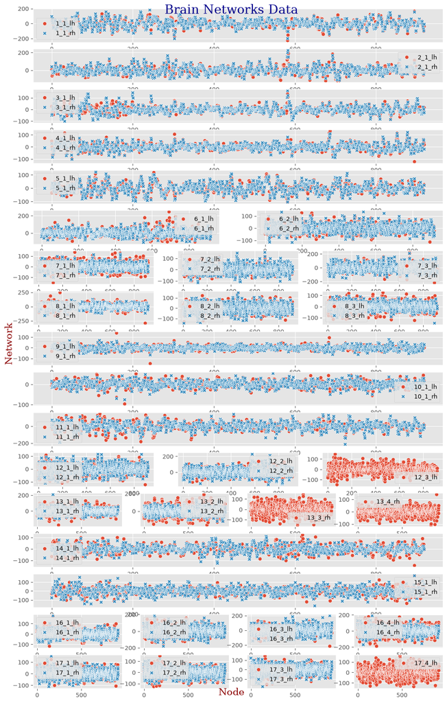

```python
fig = plt.figure(figsize=(12, 20))
for network in range(1, 18):
  network_columns = [col for col in brain_networks_merge.columns if re.match(f'^{network}_', col)]
  nodes_len = len(set(int(re.search('_([0-9]+)_', col).group(1)) for col in network_columns))
  for node in range(1, nodes_len+1):

    index = (network - 1) * nodes_len + node
    plt.subplot(17, nodes_len, index)
    data_filter = brain_networks_merge.filter(regex=f'^{network}_{node}_', axis=1)

    sns.scatterplot(data=data_filter)

# Set the super title
plt.suptitle('Brain Networks Data', fontname='serif', color='darkblue', fontsize=20, y=0.885)

# Set the super x and y labels
fig.text(0.5, 0.105, 'Node', ha='center', va='center', fontsize=16, fontname='serif', color='darkred')
fig.text(0.08, 0.5, 'Network', ha='center', va='center', rotation='vertical', fontsize=16, fontname='serif', color='darkred')

# plt.tight_layout()
plt.show()
```

### **DBSCAN**

```python
def euclidean_distance(a, b):
    return np.sqrt(np.sum((a - b)**2))

def region_query(data, point_id, eps):
    n_points = data.shape[1]
    seeds = []
    for i in range(0, n_points):
        if euclidean_distance(data[:, point_id], data[:, i]) < eps:
            seeds.append(i)
    return seeds

def expand_cluster(data, classifications, point_id, cluster_id, eps, min_points):
    seeds = region_query(data, point_id, eps)
    if len(seeds) < min_points:
        classifications[point_id] = -1
        return False
    else:
        classifications[point_id] = cluster_id
        for seed_id in seeds:
            classifications[seed_id] = cluster_id

        while len(seeds) > 0:
            current_point = seeds[0]
            results = region_query(data, current_point, eps)
            if len(results) >= min_points:
                for i in range(0, len(results)):
                    result_point = results[i]
                    if classifications[result_point] == 0 or classifications[result_point] == -1:
                        if classifications[result_point] == 0:
                            seeds.append(result_point)
                        classifications[result_point] = cluster_id
            seeds = seeds[1:]
        return True

def dbscan(data, eps, min_points):
    cluster_id = 1
    n_points = data.shape[1]
    classifications = [0]*n_points
    for point_id in range(0, n_points):
        point = data[:, point_id]
        if classifications[point_id] == 0:
            if expand_cluster(data, classifications, point_id, cluster_id, eps, min_points):
                cluster_id = cluster_id + 1
    return classifications
```

```python
data = brain_networks_merge
data = brain_networks_merge.filter(regex=f'^{17}_{4}_', axis=1)
data = brain_networks_merge.values.T

scaler = StandardScaler()
data = scaler.fit_transform(data)

eps = 7
min_points = 8

dbscan_labels = dbscan(data, eps, min_points)
dbscan_labels = [label + 1 for label in dbscan_labels]

counts = np.bincount(dbscan_labels)

for i in range(len(counts)):
    if i == 0:
        print(f"Noise points: {counts[i]}")
    else:
        print(f"Cluster {i}: {counts[i]} points")
```

```
Noise points: 468
Cluster 1: 0 points
Cluster 2: 452 points
```

Try other functions from sklearn

```python
from sklearn.cluster import KMeans, SpectralClustering, AgglomerativeClustering, OPTICS
from sklearn.mixture import GaussianMixture

data = brain_networks_merge

# K-Means
kmeans = KMeans(n_clusters=3, init='k-means++', n_init=10)
kmeans_labels = kmeans.fit_predict(data)

# Spectral Clustering
spectral = SpectralClustering(n_clusters=3, eigen_solver='arpack', n_init=10)
spectral_labels = spectral.fit_predict(data)

# Agglomerative Clustering
agglo = AgglomerativeClustering(n_clusters=3, metric='euclidean', linkage='ward')
agglo_labels = agglo.fit_predict(data)

# OPTICS
optics = OPTICS(min_samples=5, xi=0.05, min_cluster_size=0.05)
optics_labels = optics.fit_predict(data)

# Gaussian Mixture Models
gmm = GaussianMixture(n_components=3, covariance_type='full', tol=0.001)
gmm_labels = gmm.fit_predict(data)
```

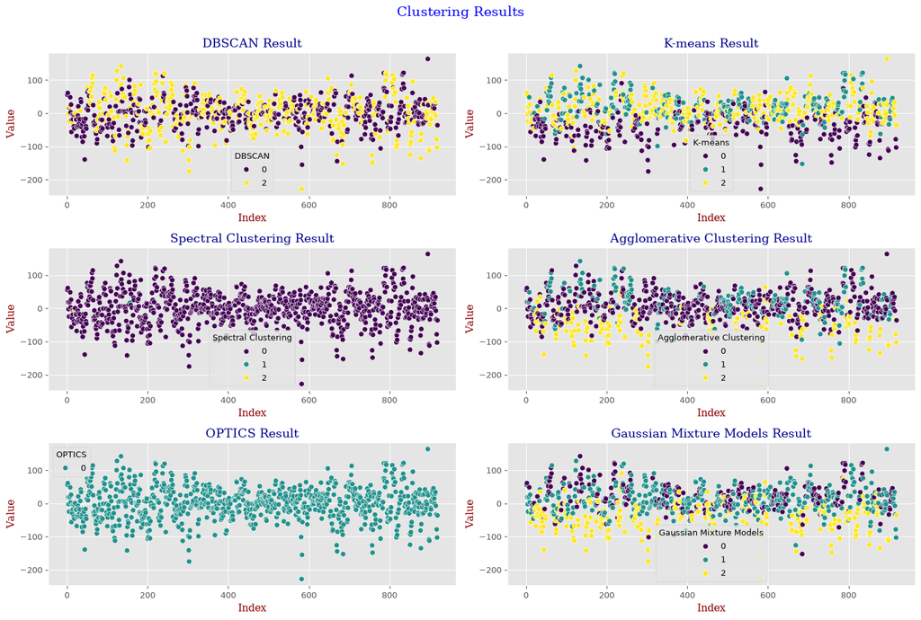

```python
model_name = ['DBSCAN', 'K-means', 'Spectral Clustering', 'Agglomerative Clustering', 'OPTICS', 'Gaussian Mixture Models']
model_labels = [dbscan_labels, kmeans_labels, spectral_labels, agglo_labels, optics_labels, gmm_labels]

plt.figure(figsize=(15,10))

for i, e in enumerate(model_name):
  labels = model_labels[i]
  plt.subplot(3, 2, i+1)
  df = brain_networks_merge.copy()
  df[e] = labels
  plt.subplot(3, 2, i+1)
  sns.scatterplot(data=df, x=df.index, y=df.columns[0], hue=e, palette='viridis')
  plt.xlabel('Index', fontname='serif', color='darkred')
  plt.ylabel('Value', fontname='serif', color='darkred')
  plt.title(f"{e} Result", fontname='serif', color='darkblue')


plt.suptitle('Clustering Results', fontname='serif', color='blue', fontsize=16, y=1.0)
plt.tight_layout()
plt.show()
```

We can have a violin plot for more clear view of how many observations in each cluster by each model

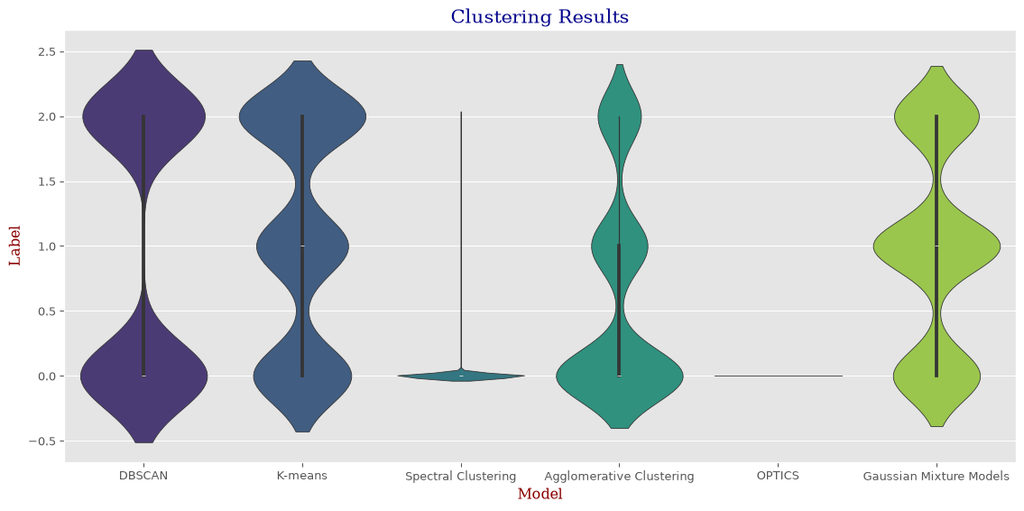

```python
df_labels = pd.DataFrame()

df_labels['DBSCAN'] = dbscan_labels
df_labels['K-means'] = kmeans_labels
df_labels['Spectral Clustering'] = spectral_labels
df_labels['Agglomerative Clustering'] = agglo_labels
df_labels['OPTICS'] = optics_labels
df_labels['Gaussian Mixture Models'] = gmm_labels

df_melt = df_labels.melt(var_name='model', value_name='label')

plt.figure(figsize=(12,6))
sns.violinplot(x='model', y='label', hue='model', data=df_melt, palette='viridis', legend=False)
plt.title('Clustering Results', fontname='serif', color='darkblue', fontsize=16)
plt.xlabel('Model', fontname='serif', color='darkred')
plt.ylabel('Label', fontname='serif', color='darkred')
plt.tight_layout()
plt.show()
```

end.